# 决策树

### 装袋法和随机森林

**装袋法**是m=p时的随机森林，是随机森林的一种特殊情况，仍旧使用MASS包中的Boston数据集

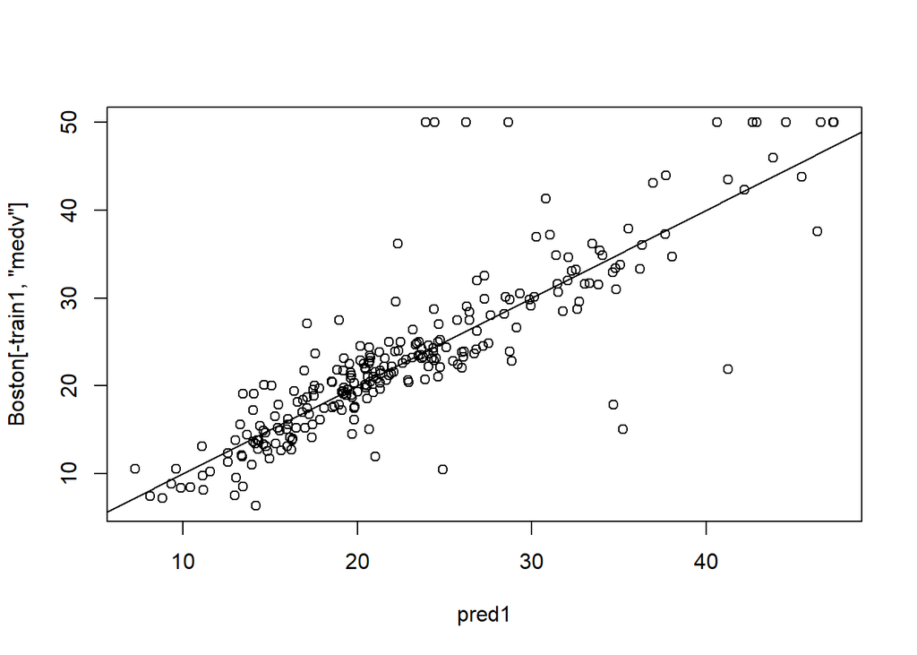

```r
library(randomForest)
set.seed(1)
fit61<-randomForest(medv~.,Boston,subset = train1,mtry=13,importance=TRUE)
#mtry=13即在树的每一个分裂点都要考虑所有预测变量，也就是执行装袋法
pred1<-predict(fit61,Boston[-train1,])
plot(pred1,Boston[-train1,"medv"])
abline(0,1)
```

```r
mean((pred1-Boston[-train1,"medv"])^2)#计算测试均方误差
```

```
## [1] 23.59273
```

**随机森林**

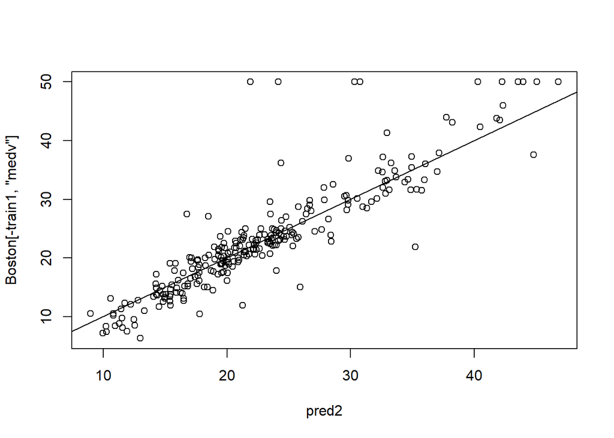

```r
library(randomForest)
set.seed(1)
fit62<-randomForest(medv~.,Boston,subset = train1,mtry=4,importance=TRUE)
#mtry=4，即树上的每个分裂点都只考虑4个预测变量
pred2<-predict(fit62,Boston[-train1,])
plot(pred2,Boston[-train1,"medv"])
abline(0,1)
```

```r
mean((pred2-Boston[-train1,"medv"])^2)#计算测试均方误差
```

```
## [1] 18.11686
```

**注意**：mtry这个参数建立回归树时默认是p/3，建立分类树时默认取$\sqrt{p}$个变量;randomForest()中还有一个参数是ntree，用来改变生成的树的数目，默认生成500棵树。

### 提升法

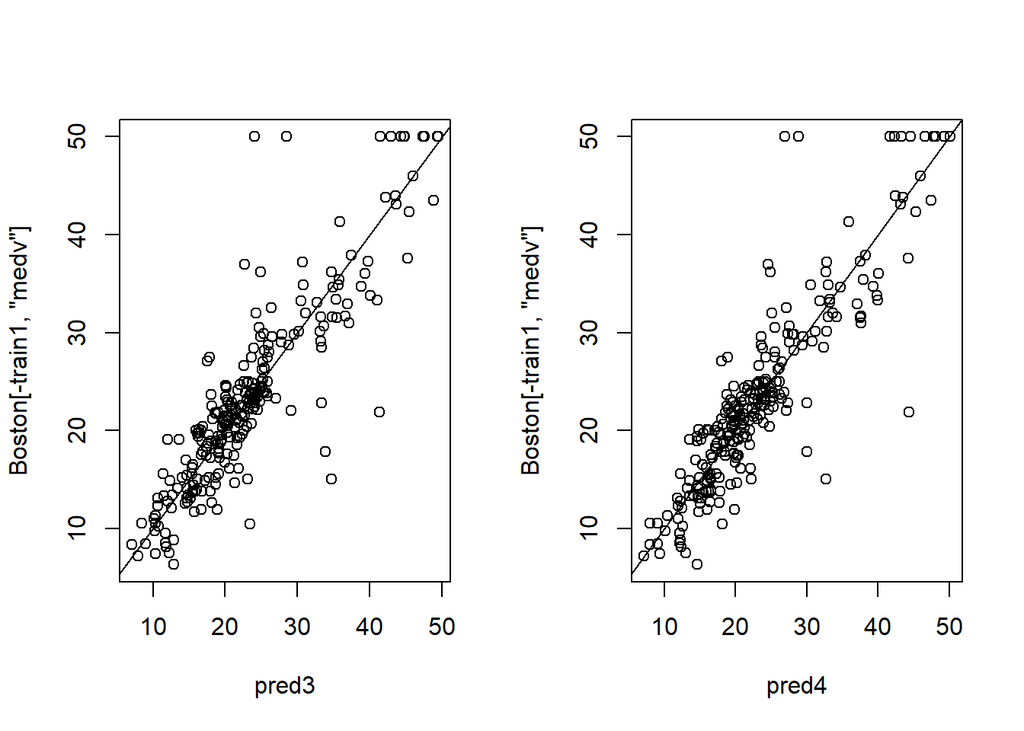

```r
library(gbm)
set.seed(1)
fit63<-gbm(medv~.,Boston[train1,],distribution="gaussian",n.trees=5000,interaction.depth=4,shrinkage=0.2,verbose=F)

fit64<-gbm(medv~.,Boston[train1,],distribution="gaussian",n.trees=5000,interaction.depth=4)

par(mfrow=c(1,2))

pred3<-predict(fit63,Boston[-train1,],n.tree=5000)
plot(pred3,Boston[-train1,"medv"])
abline(0,1)


pred4<-predict(fit64,Boston[-train1,],n.tree=5000)
plot(pred4,Boston[-train1,"medv"])
abline(0,1)
```

```r
mean((pred3-Boston[-train1,"medv"])^2)#计算测试均方误差
```

```
## [1] 20.37141
```

```r
mean((pred4-Boston[-train1,"medv"])^2)#计算测试均方误差
```

```
## [1] 18.18255
```

**注意**：gbm()中，回归问题distribution=“gaussian”，分类问题distribution=“bernoulli”，n.trees=5000说明提升法一共需要5000棵树，interaction.depth=4每棵树的深度为4，shrinkage=0.2是压缩参数$\lambda$，默认为0.001。上面两个模型的区别在于压缩参数$\lambda$

变量的重要性度量未涉及，随机森林算法可以计算变量的**相对重要程度**

# 缺失值处理

现实任务中常会遇到不完整样本，即样本的某些属性值缺失，如果简单的放弃不完整样本，仅适用无缺失值的样本来进行学习，显然是对数据信息的极大浪费。显然，有必要考虑利用有缺失属性值得训练样本样例来进行学习。

我们需解决两个问题：  
(1)如何在属性值缺失的情况下进行划分属性选择?  
(2)给定划分属性，若样本在该属性上的值缺失，如何对样本进行划分?

给定数据集D和属性a，令$\tilde{D}$表示属性a上没有缺失值的样本子集。  
对问题(1)，显然我们仅可根据$\tilde{D}$来判断属性a的优劣。

假定属性a有V个可取值,令$\tilde{D^v}$表示$\tilde{D}$中在属性a上取值为${a^v}$的样本子集。

假定我们为每个样本$x$赋予一个权重$\omega_{x}$(在决策树开始阶段，跟结点中各样本的权重初始化为1)  
$\tilde{p_{k}}$表示无缺失值样本中第k类所占比例  
$\tilde{r_{v}}$表示无缺失值样本中在属性a上取值$a^v$的样本所占比例

基于上述定义，我们可以将信息增益率的计算公式推广为：
$$Gain(D,a)=\rho(Ent(\tilde{D})-\sum_{v=1}^{V}\tilde{r_{v}}Ent(\tilde{D^v}))$$

其中
$$Ent(\tilde{D^v})=-\sum_{k=1}^{Y}\tilde{p_{k}}log_{2}\tilde{p_{k}}$$

对问题(2) 若样本$x$在划分属性a上的**取值已知**，则将$x$划入与其取值对于的子结点，且样本权值在子结点中保持为$\omega_{x}$。

若样本$x$在划分属性a上的**取值未知**，则将$x$同时划入**所有子结点**，且样本权值在与属性值$a^v$对应的子结点中调整为**$\tilde{r_{v}}$*$\omega_{x}$**;直观上看，就是让同一个样本以不同的概率划入到不同的子结点中去。(C4.5算法就使用了上述解决方案)

# 多变量决策树

将各个属性看作是一个坐标轴，则d个属性对应的样本，对应着d维空间中的一个点。对样本分类意味着，在这个空间中寻找不同样本之间的分类边界。

决策树形成的分类边界：轴平行。分类边界由若干个与坐标轴平行的分段构成。这使得结果具有较好的可解释性。

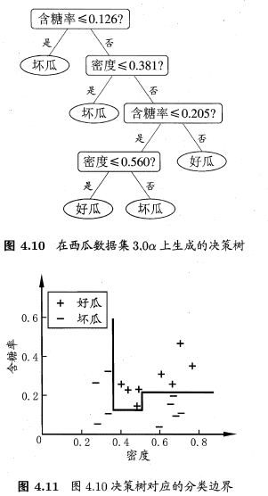

然而如果任务的分类边界较为复杂，必须用很多段才可以凑出来。

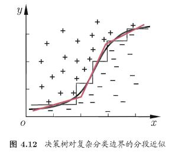

此时决策树相当复杂，进行大量的属性测试，时间开销大。

若可以使用斜的划分边界，那就省事了。

多变量决策树，可实现斜划分，非叶结点不再是某个属性，而是属性的线性组合。与传统单变量决策树不同（为每个非叶结点寻找一个最优划分属性），而是建立一个合适的线性分类器。

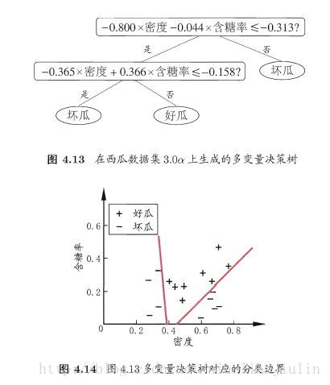